# Rプログラミング入門 データの結合（1）

Cho（ztempest0218@gmail.com）

Last Updated: 2026-05-25

**今回の内容**

- データ結合の基本的な考え方
- 縦方向の結合
  - `bind_rows()`
- 横方向の結合
  - `bind_cols()`
  - `left_join()`
  - `inner_join()`、`full_join()`、`anti_join()`
- SSDSEデータを用いた結合

**今回使用するデータ**

- SSDSE.rds

上記データを[Rプログラミング入門授業用サイト](https://ztempest0218.github.io/R-Programming/)からダウンロードしてください。

注: Rの学習には**「インストール」「データの読み込み」「データの結合」という三つの壁**がある。乗り越えると、オリジナルのレゴを組み立てるように、さまざまなデータを自由に組み合わせながら、面白い研究ができるようになる。

# 1 データ結合とは何か

実際の分析では、1つのデータファイルだけで分析が完結することは少ない。人口データ、所得データ、教育データ、選挙データ、企業財務データなど、複数のデータを組み合わせて初めて分析できる場合が多い。

**e-Stat**から、日本のマクロデータや都道府県別データを入手できる。ただし、データは統一的に整備されておらず、失業率は「労働力調査」、犯罪率は「犯罪統計」、賃金は「賃金構造基本統計調査」のように、別々の統計に**分散**している。 そのため、簡単な分析であっても、自らデータを収集・結合し、分析用データセットを構築する必要がある。

[figure not shown]

Source: e-Stat

（構造化）データの結合には、大きく分けて2つの方向がある。

| 結合の方向 | 目的 | 代表的な関数 |
| --- | --- | --- |
| 縦方向の結合 | 観測値（行）を増やす | `bind_rows()` |
| 横方向の結合 | 変数（列）を増やす | `bind_cols()`、`left_join()` |

**縦方向の結合は、同じ形式のデータを下に追加する作業である。**例えば、2025年のデータと2026年のデータ、Aクラスの学生データとBクラスの学生データを1つにまとめる場合である。

**横方向の結合は、同じ観測値に対して別の変数を追加する作業である。**例えば、学生の基本情報に試験成績を追加する、都道府県の人口データに教育データを追加する場合である。

ただし、横方向の結合では、**何と何が同じ観測値であるか**を明確にしなければならない。その対応関係を表す変数を **key**と呼ぶ（情報系では key、統計・行政・計量経済学などの社会科学では **識別子** や **identifier** と呼ぶことが多い。）。学生データであれば学生ID、都道府県データであれば都道府県名や都道府県コード、パネルデータであれば都道府県名と年の組み合わせが key になる。

今日の授業で使う関数はすべて `dplyr` に含まれるため、パッケージを読み込む必要がある。

```r
library(dplyr)
rm(list = ls())
```

# 2 縦方向の結合

縦方向の結合とは、データを下に積み重ねることである。列の構造が同じで、観測値だけが異なる場合に使用する。

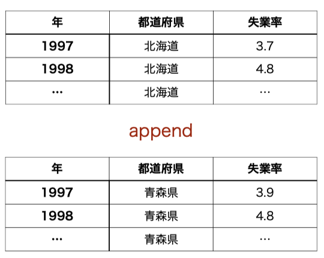

例：都道府県別のデータを縦方向に結合

まず、AクラスとBクラスの小さな学生データを作成してみよう。

```r
class_a <- data.frame(
  id = c(1, 2, 3),
  name = c("Aoki", "Sato", "Tanaka"),
  score = c(82, 75, 91)
)

class_a
```

| id | name | score |
| --- | --- | --- |
| 1 | Aoki | 82 |
| 2 | Sato | 75 |
| 3 | Tanaka | 91 |

```r
class_b <- data.frame(
  id = c(4, 5, 6),
  name = c("Yamada", "Suzuki", "Kato"),
  score = c(68, 88, 79)
)


class_b
```

| id | name | score |
| --- | --- | --- |
| 4 | Yamada | 68 |
| 5 | Suzuki | 88 |
| 6 | Kato | 79 |

この2つのデータは、どちらも `id`、`name`、`score` という同じ列を持っている。したがって、縦方向に結合できる。

```r
students <- bind_rows(class_a, class_b)
students
```

| id | name | score |
| --- | --- | --- |
| 1 | Aoki | 82 |
| 2 | Sato | 75 |
| 3 | Tanaka | 91 |
| 4 | Yamada | 68 |
| 5 | Suzuki | 88 |
| 6 | Kato | 79 |

`bind_rows()` を使うと、1つ目のデータの下に2つ目のデータが追加される。観測値（行）が増えるだけで、変数（列）は増えない。

## 2.1 データの出所を残す

縦方向に結合するときは、どのデータから来た観測値なのかを残しておくと便利である。特に、年度別データ、地域別データ、調査回別データをまとめる場合、出所の情報を失うと後で困る。`mutate`関数で新たに変数を追加する。

```r
class_a <- mutate(class_a, class = "A")
class_b <- mutate(class_b, class = "B")

students <- bind_rows(class_a, class_b)
students
```

| id | name | score | class |
| --- | --- | --- | --- |
| 1 | Aoki | 82 | A |
| 2 | Sato | 75 | A |
| 3 | Tanaka | 91 | A |
| 4 | Yamada | 68 | B |
| 5 | Suzuki | 88 | B |
| 6 | Kato | 79 | B |

このように、結合前に `class` という列を追加しておけば、結合後も各学生がどちらのクラスに所属していたかを確認できる。

## 2.2 列が完全に一致しない場合

実際のデータでは、片方のデータにしか存在しない列があることも多い。`bind_rows()` は、列名で結合し、存在しない値には欠損値 `NA` （not available）を入れる。

```r
class_c <- data.frame(
  id = c(7, 8, 9),
  name = c("Ito", "Mori", "Tanoue"),
  score = c(84, 73, 55),
  report = c("submitted", "late", "late"),
  class = c("C", "C", "C")
)

bind_rows(class_a, class_c)
```

| id | name | score | class | report |
| --- | --- | --- | --- | --- |
| 1 | Aoki | 82 | A | NA |
| 2 | Sato | 75 | A | NA |
| 3 | Tanaka | 91 | A | NA |
| 7 | Ito | 84 | C | submitted |
| 8 | Mori | 73 | C | late |
| 9 | Tanoue | 55 | C | late |

`class_a` には `report` という列が存在しないため、結合後は `NA` になる。これはエラーではないが、意図しない欠損値が発生していないか確認する必要がある。

なお、base R の `rbind()` でも縦方向の結合は可能である。しかし、列名や列数が完全に一致しないとエラーになりやすい。データ前処理では、`dplyr`の`bind_rows()` の方が柔軟で使いやすい。

# 3 横方向の結合

横方向の結合とは、同じ観測値に対して列を追加することである。例えば、学生の基本情報に試験成績を追加する場合である。

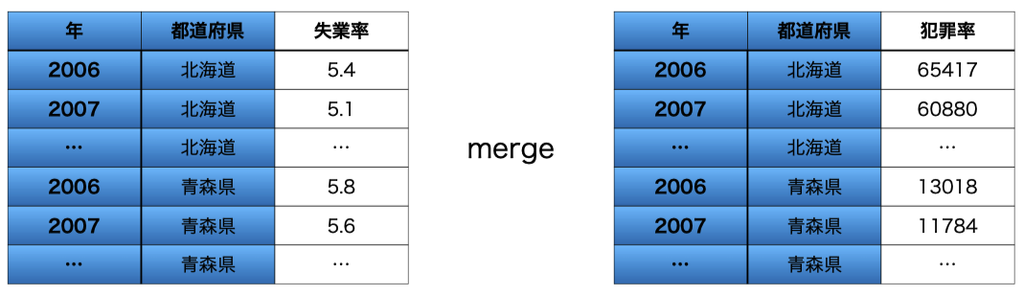

例：失業率と犯罪率のパネルデータを横方向に結合

横方向の結合には、2つの考え方がある。

- 行の順番が完全に一致していること（通し番号:1,2,3,4,5,…）を前提に、列をそのまま横に追加する
- **key を使って、同じ観測値を対応させてから列を追加する**

初心者がよく間違えるのは、行の順番だけを信じて横方向に結合してしまうことである。行の順番が少しでもずれていると、別人の成績が別人の情報に結合される。

## 3.1 `bind_cols()`による横方向の結合

まず、行の順番が完全に一致しているデータを考える。ここで二つのデータセット、①学生の基本情報、②学生の成績データを考える。

```r
# 基本情報①
student_basic <- data.frame(
  id = c(1, 2, 3, 4),
  name = c("Aoki", "Sato", "Tanaka", "Yamada"),
  gender = c("F", "M", "F", "M")
)

# 成績データ②
student_score <- data.frame(
  math = c(82, 75, 91, 68),
  english = c(78, 80, 88, 72)
)

# 横方向に結合
bind_cols(student_basic, student_score)
```

| id | name | gender | math | english |
| --- | --- | --- | --- | --- |
| 1 | Aoki | F | 82 | 78 |
| 2 | Sato | M | 75 | 80 |
| 3 | Tanaka | F | 91 | 88 |
| 4 | Yamada | M | 68 | 72 |

この場合、`student_basic` の1行目と `student_score` の1行目が同じ学生を表しているため、正しく結合できる。**しかし、行の順番がずれている場合、`bind_cols()` はそのずれに気づかない。**（小さいデータなら対応できるかもしれない。しかし、何万行もあるデータでは、1行でも脱落すると全体がずれ、重大な事故につながりやすい。）

```r
# 失敗例
student_score_wrong <- data.frame(
  id = c(3, 1, 4, 2),
  math = c(91, 82, 68, 75),
  english = c(88, 78, 72, 80)
)

bind_cols(
  student_basic,
  select(student_score_wrong, math, english)
)
```

| id | name | gender | math | english |
| --- | --- | --- | --- | --- |
| 1 | Aoki | F | 91 | 88 |
| 2 | Sato | M | 82 | 78 |
| 3 | Tanaka | F | 68 | 72 |
| 4 | Yamada | M | 75 | 80 |

この結果は一見すると問題がないように見える。しかし、1行目の Aoki に、実際には Tanaka の成績が結合されている。これは非常に危険である。

そのため、**横方向の結合では、基本的に key を使う方法を優先**する。

## 3.2 keyによる横方向の結合

key による結合では、行の順番ではなく、共通する識別子（**identifier**）の値を使って観測値を対応させる。Rにおいて、keyで結合するとき、`join`系関数を使用する。下記は、学生情報を左側、学生成績を右側とし、右側のデータを左側に結合する`left_join()`の使用例である。

```r
# 成績データに学生idを追加
student_score <-student_score %>%
  mutate(id = c(1, 2, 3, 4) )

# 学生情報
left_join(
  student_basic,
  student_score,
  by = "id"
)
```

| id | name | gender | math | english |
| --- | --- | --- | --- | --- |
| 1 | Aoki | F | 82 | 78 |
| 2 | Sato | M | 75 | 80 |
| 3 | Tanaka | F | 91 | 88 |
| 4 | Yamada | M | 68 | 72 |

`id` を key として指定したため、行の順番が違っていても、正しい学生に正しい成績が結合される。

`left_join(x, y, by = "key")` は、左側のデータ `x` を基準にして、右側のデータ `y` から対応する列を追加する関数である。対応する key が右側に存在しない場合、追加される列は `NA` になる。

# 4 joinの種類

横方向の結合では、どの観測値を残すかによって join の種類が変わる。ここでは、学生の基本情報と試験成績を例に確認する。結合の考え方は集合で表すと理解しやすいため、ここでは左のデータを A、右のデータを B とする。

```r
# A 基本情報
students <- data.frame(
  id = c(1, 2, 3, 4, 5),
  name = c("Aoki", "Sato", "Tanaka", "Yamada", "Suzuki")
)

students
```

| id | name |
| --- | --- |
| 1 | Aoki |
| 2 | Sato |
| 3 | Tanaka |
| 4 | Yamada |
| 5 | Suzuki |

```r
# B 成績
scores <- data.frame(
  id = c(1, 2, 4, 6),
  math = c(82, 75, 68, 90)
)

scores
```

| id | math |
| --- | --- |
| 1 | 82 |
| 2 | 75 |
| 4 | 68 |
| 6 | 90 |

この例では、`students` には id 5 の学生が存在するが、`scores` には id 5 が存在しない。一方で、`scores` には id 6 が存在するが、`students` には id 6 が存在しない。

## 4.1 left_join

`left_join()` は、左側のデータを基準にする。分析で最もよく使われる join である。集合で表すと、$A$である。

```r
left_join(students, scores, by = "id")
```

| id | name | math |
| --- | --- | --- |
| 1 | Aoki | 82 |
| 2 | Sato | 75 |
| 3 | Tanaka | NA |
| 4 | Yamada | 68 |
| 5 | Suzuki | NA |

id 5 は `students` に存在するため残るが、成績データがないため `math` は `NA` になる。id 6 は左側の `students` に存在しないため、結果には残らない。

## 4.2 inner_join

`inner_join()` は、両方のデータに存在する key だけを残す。共通しないものは削除される。集合で表すと、積集合$A \cap B$である。

```r
inner_join(students, scores, by = "id")
```

| id | name | math |
| --- | --- | --- |
| 1 | Aoki | 82 |
| 2 | Sato | 75 |
| 4 | Yamada | 68 |

id 1、2、4 は両方のデータに存在するため残る。id 3、5、6 はどちらか一方にしか存在しないため、結果から落ちる。

`inner_join()` は欠損を避けられるように見えるが、観測値が減るため注意が必要である。なぜ行数が減ったのかを説明できないまま使ってはいけない。

## 4.3 full_join

`full_join()` は、どちらか一方に存在する key をすべて残す。集合で表すと、和集合$A \cup B$である。

```r
full_join(students, scores, by = "id")
```

| id | name | math |
| --- | --- | --- |
| 1 | Aoki | 82 |
| 2 | Sato | 75 |
| 3 | Tanaka | NA |
| 4 | Yamada | 68 |
| 5 | Suzuki | NA |
| 6 | NA | 90 |

両方のデータに存在しない部分は `NA` になる。データの対応状況を確認したいときに便利である。（統計ソフトStataでは標準である。）

## 4.4 anti_join

`anti_join(A, B)` は、左側のデータに存在するが、右側のデータには存在しない観測値を抽出する。集合で表すと、差集合$A \setminus B$である。

```r
anti_join(students, scores, by = "id")
```

| id | name |
| --- | --- |
| 3 | Tanaka |
| 5 | Suzuki |

これは、結合できなかった観測値を確認するために非常に有用である。データ結合では、結合そのものよりも、**結合できなかったデータを確認すること**が重要である。

## 4.5 結合前に確認すること

データを結合する前には、最低限次の点を確認する。

| 確認項目 | 確認する理由 |
| --- | --- |
| key は存在するか | 共通する変数がなければ join できない |
| key の名前は同じか | 変数名が異なる場合は `by = c("x_key" = "y_key")` が必要 |
| key の型は同じか | 片方が数値、片方が文字列だと結合できない |
| key は重複していないか | 意図しない行の増加が起きる |
| 行数はどう変化したか | 結合ミスを発見しやすい |

key の重複は、`count()` で確認できる。

```r
scores_dup <- data.frame(
  id = c(1, 1, 2, 4),
  subject = c("math", "english", "math", "math"),
  score = c(82, 78, 75, 68)
)

count(scores_dup, id)
```

| id | n |
| --- | --- |
| 1 | 2 |
| 2 | 1 |
| 4 | 1 |

id 1 が2回登場している。このようなデータをそのまま結合すると、行数が増える。

```r
left_join(students, scores_dup, by = "id")
```

| id | name | subject | score |
| --- | --- | --- | --- |
| 1 | Aoki | math | 82 |
| 1 | Aoki | english | 78 |
| 2 | Sato | math | 75 |
| 3 | Tanaka | NA | NA |
| 4 | Yamada | math | 68 |
| 5 | Suzuki | NA | NA |

この結果は必ずしも間違いではない。1人の学生が複数科目の成績を持つ場合、行が増えるのは自然である。しかし、「学生1人につき1行」のデータを作りたい場合は、結合前に集計や整形が必要である。この問題は次回の授業で扱う。

# 5 SSDSEデータを用いた結合

ここからは、SSDSE データを用いて、練習として実際にデータを分割し、再び結合してみる。実際の研究では、データを結合する操作そのものよりも、どのデータを使うか、またそれらをどう組み合わせれば研究課題を検証できるかを考える段階で、多くのブレインストーミングが必要になる。

```r
# メモリを空にする
rm(list = ls())

# パッケージを読み込む
library(dplyr)

# working directory を適宜設定
# setwd("...")

# データを読み込む
raw <- readRDS("./data/SSDSE.rds")

dim(raw)
```

```
## [1] 564 112
```

```r
names(raw)[1:20]
```

```
##  [1] "SSDSE.B.2026" "Code"         "Prefecture"   "A1101"        "A110101"
##  [6] "A110102"      "A1102"        "A110201"      "A110202"      "A1301"
## [11] "A130101"      "A130102"      "A1302"        "A130201"      "A130202"
## [16] "A1303"        "A130301"      "A130302"      "A4101"        "A410101"
```

SSDSE データには、都道府県・年ごとに、人口、出生、婚姻、教育など多くの変数が含まれている。ここでは、1つの大きなデータから、人口データ、出生・婚姻データ、教育データを作成し、それらを key で結合する。

## 5.1 人口データを作る

```r
pop <- raw %>%
  select(
    SSDSE.B.2026,
    Prefecture,
    A1101,
    A1301
  ) %>%
  rename(
    year = SSDSE.B.2026,
    prefecture = Prefecture,
    pop = A1101,
    pop_under15 = A1301
  )

head(pop)
```

|  | year | prefecture | pop | pop_under15 |
| --- | --- | --- | --- | --- |
| 1 | 2023 | 北海道 | 5092000 | 514000 |
| 2 | 2022 | 北海道 | 5140000 | 530000 |
| 3 | 2021 | 北海道 | 5183000 | 544000 |
| 4 | 2020 | 北海道 | 5224614 | 555804 |
| 5 | 2019 | 北海道 | 5259000 | 565000 |
| 6 | 2018 | 北海道 | 5293000 | 577000 |

## 5.2 出生・婚姻データを作る

```r
birth_marriage <- raw %>%
  select(
    SSDSE.B.2026,
    Prefecture,
    A4101,
    A4103,
    A9101
  ) %>%
  rename(
    year = SSDSE.B.2026,
    prefecture = Prefecture,
    births = A4101,
    tfr = A4103,
    marriages = A9101
  )

head(birth_marriage)
```

|  | year | prefecture | births | tfr | marriages |
| --- | --- | --- | --- | --- | --- |
| 1 | 2023 | 北海道 | 24430 | 1.06 | 17281 |
| 2 | 2022 | 北海道 | 26407 | 1.12 | 18665 |
| 3 | 2021 | 北海道 | 28762 | 1.20 | 19326 |
| 4 | 2020 | 北海道 | 29523 | 1.21 | 20904 |
| 5 | 2019 | 北海道 | 31020 | 1.24 | 23417 |
| 6 | 2018 | 北海道 | 32642 | 1.27 | 22916 |

## 5.3 教育データを作る

```r
education <- raw %>%
  select(
    SSDSE.B.2026,
    Prefecture,
    E2101,
    E2401,
    E2501
  ) %>%
  rename(
    year = SSDSE.B.2026,
    prefecture = Prefecture,
    elementary_schools = E2101,
    elementary_teachers = E2401,
    elementary_students = E2501
  )

head(education)
```

|  | year | prefecture | elementary_schools | elementary_teachers | elementary_students |
| --- | --- | --- | --- | --- | --- |
| 1 | 2023 | 北海道 | 950 | 18691 | 221397 |
| 2 | 2022 | 北海道 | 966 | 18900 | 227372 |
| 3 | 2021 | 北海道 | 984 | 19028 | 231714 |
| 4 | 2020 | 北海道 | 999 | 19071 | 236396 |
| 5 | 2019 | 北海道 | 1027 | 19145 | 239792 |
| 6 | 2018 | 北海道 | 1045 | 19108 | 243511 |

## 5.4 keyの重複を確認する

今回のデータでは、1つの都道府県・1つの年につき1行でなければならない。したがって、key は `year` と `prefecture` の組み合わせである。まず `count(year, prefecture)` を使い、それぞれの組み合わせが何回出てくるかを数える。 このとき、`count()` は件数を表す列 `n` を自動で作る。

```r
pop %>%
  count(year, prefecture) %>%
  filter(n > 1)
```

| year | prefecture | n |
| --- | --- | --- |

何も表示されなければ、重複は存在しない。`birth_marriage` と `education` についても同じように確認できる。

```r
birth_marriage %>%
  count(year, prefecture) %>%
  filter(n > 1)
```

| year | prefecture | n |
| --- | --- | --- |

```r
education %>%
  count(year, prefecture) %>%
  filter(n > 1)
```

| year | prefecture | n |
| --- | --- | --- |

## 5.5 left_joinで横方向に結合する

人口データを基準にして、出生・婚姻データ、教育データを結合する。

```r
ssdse_joined <- pop %>%
  left_join(
    birth_marriage,
    by = c("year", "prefecture")
  ) %>%
  left_join(
    education,
    by = c("year", "prefecture")
  )

head(ssdse_joined)
```

|  | year | prefecture | pop | pop_under15 | births | tfr | marriages | elementary_schools | elementary_teachers | elementary_students |
| --- | --- | --- | --- | --- | --- | --- | --- | --- | --- | --- |
| 1 | 2023 | 北海道 | 5092000 | 514000 | 24430 | 1.06 | 17281 | 950 | 18691 | 221397 |
| 2 | 2022 | 北海道 | 5140000 | 530000 | 26407 | 1.12 | 18665 | 966 | 18900 | 227372 |
| 3 | 2021 | 北海道 | 5183000 | 544000 | 28762 | 1.20 | 19326 | 984 | 19028 | 231714 |
| 4 | 2020 | 北海道 | 5224614 | 555804 | 29523 | 1.21 | 20904 | 999 | 19071 | 236396 |
| 5 | 2019 | 北海道 | 5259000 | 565000 | 31020 | 1.24 | 23417 | 1027 | 19145 | 239792 |
| 6 | 2018 | 北海道 | 5293000 | 577000 | 32642 | 1.27 | 22916 | 1045 | 19108 | 243511 |

結合後、行数が変化していないか確認する。

```r
nrow(pop)
```

```
## [1] 564
```

```r
nrow(ssdse_joined)
```

```
## [1] 564
```

`left_join()` を使ったので、基準となる `pop` の行数と同じであることが期待される。もし行数が増えたり減ったりした場合は、key の指定や重複を確認する必要がある。

欠損値も確認しておこう。`colSum`が列ごとに合計する関数である。

```r
colSums(is.na(ssdse_joined))
```

```
##                year          prefecture                 pop         pop_under15
##                   0                   0                   0                   0
##              births                 tfr           marriages  elementary_schools
##                   0                   0                   0                   0
## elementary_teachers elementary_students
##                   0                   0
```

欠損値が多い場合、key が一致していない、片方のデータに存在しない地域・年がある、または元データに欠損値が含まれている可能性がある。

## 5.6 結合後に変数を作成する

結合が終われば、複数のデータにまたがる変数を使って新しい変数を作成できる。

```r
ssdse_final <- ssdse_joined %>%
  mutate(
    under15_ratio = pop_under15 / pop,
    birth_per1000 = births / pop * 1000,
    marriage_per1000 = marriages / pop * 1000,
    students_per_school = elementary_students / elementary_schools
  )

head(ssdse_final)
```

|  | year | prefecture | pop | pop_under15 | births | tfr | marriages | elementary_schools | elementary_teachers | elementary_students | under15_ratio | birth_per1000 | marriage_per1000 | students_per_school |
| --- | --- | --- | --- | --- | --- | --- | --- | --- | --- | --- | --- | --- | --- | --- |
| 1 | 2023 | 北海道 | 5092000 | 514000 | 24430 | 1.06 | 17281 | 950 | 18691 | 221397 | 0.1009427 | 4.797722 | 3.393755 | 233.0495 |
| 2 | 2022 | 北海道 | 5140000 | 530000 | 26407 | 1.12 | 18665 | 966 | 18900 | 227372 | 0.1031128 | 5.137549 | 3.631323 | 235.3747 |
| 3 | 2021 | 北海道 | 5183000 | 544000 | 28762 | 1.20 | 19326 | 984 | 19028 | 231714 | 0.1049585 | 5.549296 | 3.728729 | 235.4817 |
| 4 | 2020 | 北海道 | 5224614 | 555804 | 29523 | 1.21 | 20904 | 999 | 19071 | 236396 | 0.1063818 | 5.650752 | 4.001061 | 236.6326 |
| 5 | 2019 | 北海道 | 5259000 | 565000 | 31020 | 1.24 | 23417 | 1027 | 19145 | 239792 | 0.1074349 | 5.898460 | 4.452748 | 233.4878 |
| 6 | 2018 | 北海道 | 5293000 | 577000 | 32642 | 1.27 | 22916 | 1045 | 19108 | 243511 | 0.1090119 | 6.167013 | 4.329492 | 233.0249 |

このように、人口データ、出生・婚姻データ、教育データを結合することで、分析に使いやすいデータを作ることができる。

# 6 SSDSEデータを縦方向に結合する

最後に、SSDSE データを地域ごとに分けてから、縦方向に結合してみよう。

```r
tokyo <- ssdse_final %>%
  filter(prefecture == "東京都")

kanagawa <- ssdse_final %>%
  filter(prefecture == "神奈川県")

saitama <- ssdse_final %>%
  filter(prefecture == "埼玉県")

chiba <- ssdse_final %>%
  filter(prefecture == "千葉県")
```

これらは、すべて同じ列構造を持つデータである。したがって、`bind_rows()` で縦方向に結合できる。

```r
capital_area <- bind_rows(
  tokyo,
  kanagawa,
  saitama,
  chiba
)

capital_area %>%
  select(year, prefecture, pop, birth_per1000, marriage_per1000) %>%
  head()
```

|  | year | prefecture | pop | birth_per1000 | marriage_per1000 |
| --- | --- | --- | --- | --- | --- |
| 1 | 2023 | 東京都 | 14086000 | 6.130058 | 5.095414 |
| 2 | 2022 | 東京都 | 14038000 | 6.489315 | 5.355393 |
| 3 | 2021 | 東京都 | 14010000 | 6.809707 | 4.983084 |
| 4 | 2020 | 東京都 | 14047594 | 7.094525 | 5.262894 |
| 5 | 2019 | 東京都 | 14007000 | 7.269080 | 6.143999 |
| 6 | 2018 | 東京都 | 13887000 | 7.715849 | 5.956362 |

都道府県ごとに何年分のデータがあるかを確認する。

```r
capital_area %>%
  count(prefecture)
```

| prefecture | n |
| --- | --- |
| 千葉県 | 12 |
| 埼玉県 | 12 |
| 東京都 | 12 |
| 神奈川県 | 12 |

この例では、首都圏4都県のデータを縦方向に結合した。縦方向の結合では、列の意味が同じであることが重要である。例えば、片方のデータでは人口が「人」、もう片方では「千人」で記録されている場合、そのまま結合してはいけない。

# 7 データ結合のコツ

今回のポイントは以下の通りである。

- 縦方向の結合は、行を増やす作業であり、`bind_rows()` を使う。
- 横方向の結合は、列を増やす作業である。
  - `bind_cols()` は行の順番が完全に一致している場合にのみ使う。
  - 実務では、key を指定して `left_join()` を使うことが多い。
  - join の前には、key の存在、型、重複を確認する。
  - join の後には、行数と欠損値を確認する。

データ結合は、単に複数の表をくっつける作業ではない。どの観測値とどの観測値が対応しているのかを明確にし、結合後にデータの構造が壊れていないかを確認する作業である。

# 8 練習問題

今回は課題はないが、練習問題に取り組んだり、各自が持っているデータで試したりしてほしい。データ結合は、研究の可能性を無限に広げる重要なスキルである。

## 8.1 練習1

下記の2つのデータを作成し、`bind_rows()` で縦方向に結合しなさい。

```r
team_1 <- data.frame(
  id = c(1, 2, 3),
  name = c("A", "B", "C"),
  score = c(70, 85, 90)
)

team_2 <- data.frame(
  id = c(4, 5),
  name = c("D", "E"),
  score = c(88, 76)
)
```

## 8.2 練習2

下記の2つのデータを `id` を key として `left_join()` で結合しなさい。

```r
basic <- data.frame(
  id = c(1, 2, 3, 4),
  name = c("Aoki", "Sato", "Tanaka", "Yamada")
)

exam <- data.frame(
  id = c(2, 4, 1),
  score = c(80, 90, 75)
)
```

結合後、どの学生の `score` が `NA` になるか確認しなさい。